# Decisiontreemodel

Parv Bhargava

2023-12-13

```r
library(rpart)
library(rpart.plot)
library(caret)
library(broom)
library(tidyverse)
library(MASS)
library(ROCR)
Train <- read.csv("data\\train.csv")
Test <- read.csv("data\\test.csv")
```

**Column Datatype Changes - Testing Data**: Conversion of certain columns to factors based on their ordinal nature.

```r
Test$Inflight.wifi.service = as.factor(Test$Inflight.wifi.service)
Test$Departure.Arrival.time.convenient = as.factor(Test$Departure.Arrival.time.convenient)
Test$Ease.of.Online.booking = as.factor(Test$Ease.of.Online.booking)
Test$Gate.location = as.factor(Test$Gate.location)
Test$Food.and.drink = as.factor(Test$Food.and.drink)
Test$Online.boarding = as.factor(Test$Online.boarding)
Test$Seat.comfort = as.factor(Test$Seat.comfort)
Test$Inflight.entertainment = as.factor(Test$Inflight.entertainment)
Test$On.board.service = as.factor(Test$On.board.service)
Test$Leg.room.service = as.factor(Test$Leg.room.service)
Test$Baggage.handling = as.factor(Test$Baggage.handling)
Test$Checkin.service = as.factor(Test$Checkin.service)
Test$Inflight.service = as.factor(Test$Inflight.service)
Test$Cleanliness = as.factor(Test$Cleanliness)
```

**Column Datatype Changes - Training Data**: Similar data type conversions for training data.

```r
#Column datatype Changes - Training Data - As Columns has ordinal its better to convert into factor

Train$Inflight.wifi.service = as.factor(Train$Inflight.wifi.service)
Train$Departure.Arrival.time.convenient = as.factor(Train$Departure.Arrival.time.convenient)
Train$Ease.of.Online.booking = as.factor(Train$Ease.of.Online.booking)
Train$Gate.location = as.factor(Train$Gate.location)
Train$Food.and.drink = as.factor(Train$Food.and.drink)
Train$Online.boarding = as.factor(Train$Online.boarding)
Train$Seat.comfort = as.factor(Train$Seat.comfort)
Train$Inflight.entertainment = as.factor(Train$Inflight.entertainment)
Train$On.board.service = as.factor(Train$On.board.service)
Train$Leg.room.service = as.factor(Train$Leg.room.service)
Train$Baggage.handling = as.factor(Train$Baggage.handling)
Train$Checkin.service = as.factor(Train$Checkin.service)
Train$Inflight.service = as.factor(Train$Inflight.service)
Train$Cleanliness = as.factor(Train$Cleanliness)
```

**Replacing NA Values in Training Data - Arrival Delay in Minutes**: Handling missing values in the training dataset.

```r
#Replacing NA Values in Training Data - Arrival Delay in Minutes
NA.position <- which(is.na(Train$Arrival.Delay.in.Minutes))
Train$Arrival.Delay.in.Minutes[NA.position] = mean(Train$Arrival.Delay.in.Minutes, na.rm = TRUE)
```

**Replacing NA Values in Testing Data - Arrival Delay in Minutes**: Handling missing values in the testing dataset.

```r
#Replacing NA Values in Testing Data - Arrival Delay in Minutes
NA.position1 <- which(is.na(Test$Arrival.Delay.in.Minutes))
Test$Arrival.Delay.in.Minutes[NA.position1] = mean(Test$Arrival.Delay.in.Minutes, na.rm = TRUE)
```

**Analyzing the Importance of Variable Using the Variable Importance Plot**: Analysis to identify significant variables.

```r
#Analyzing the Importance of variable using the Variable Importance Plot
varImp(tree)
```

```
##                                      Overall
## Age                                 178.5503
## Arrival.Delay.in.Minutes            184.3497
## Baggage.handling                   1182.1223
## Checkin.service                    2579.5914
## Class                             19424.6440
## Cleanliness                         778.8102
## Ease.of.Online.booking             1821.1027
## Inflight.entertainment            13164.1445
## Inflight.service                   1216.5199
## Inflight.wifi.service             20748.8184
## Leg.room.service                   3784.7539
## On.board.service                   1227.2620
## Online.boarding                   19436.9550
## Seat.comfort                       1045.1440
## Type.of.Travel                    17950.0202
## Gender                                0.0000
## Customer.Type                         0.0000
## Flight.Distance                       0.0000
## Departure.Arrival.time.convenient     0.0000
## Gate.location                         0.0000
## Food.and.drink                        0.0000
## Departure.Delay.in.Minutes            0.0000
```

**Re-running the Model with Significant Variables**: Building the model with chosen variables.

```r
#Re-running the model with significant variables
tree1 = rpart(satisfaction ~  Age + Type.of.Travel + Class + Inflight.wifi.service +
                Ease.of.Online.booking + Online.boarding + Seat.comfort +
               Inflight.entertainment + On.board.service + Leg.room.service +
               Baggage.handling + Checkin.service + Inflight.service +
               Cleanliness + Arrival.Delay.in.Minutes,data = Train,
             method = 'class', minbucket=25)
```

**Visualizing the Decision Tree**: Displaying the structure of the decision tree.

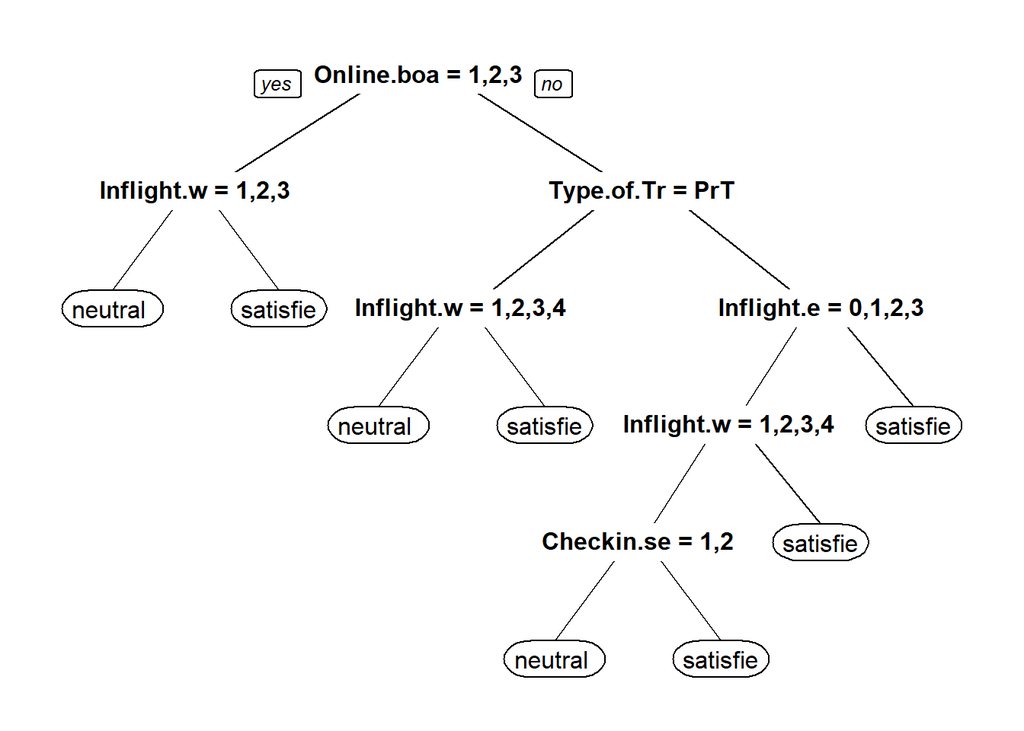

```r
#Visualizaing the Decision tree
prp(tree1)
```

**Define Cross-validation Experiment**: Setting up the cross-validation process.

```r
# Define cross-validation experiment
numFolds = trainControl( method = "cv", number = 10 )
cpGrid = expand.grid( .cp = seq(0.01,0.5,0.01))
```

**Perform the Cross-validation**: Executing the cross-validation.

```r
# Perform the cross validation
train(satisfaction ~  Age + Type.of.Travel + Class + Inflight.wifi.service +
        Ease.of.Online.booking + Online.boarding + Seat.comfort +
        Inflight.entertainment + On.board.service + Leg.room.service +
        Baggage.handling + Checkin.service + Inflight.service +
        Cleanliness + Arrival.Delay.in.Minutes,
      data = Train, method = "rpart", trControl = numFolds, tuneGrid = cpGrid )
```

```
## CART
##
## 103904 samples
##     15 predictor
##      2 classes: 'neutral or dissatisfied', 'satisfied'
##
## No pre-processing
## Resampling: Cross-Validated (10 fold)
## Summary of sample sizes: 93514, 93514, 93513, 93514, 93513, 93514, ...
## Resampling results across tuning parameters:
##
##   cp    Accuracy   Kappa
##   0.01  0.8694564  0.7288834
##   0.02  0.8628830  0.7168133
##   0.03  0.8435863  0.6770448
##   0.04  0.8435863  0.6770448
##   0.05  0.8435863  0.6770448
##   0.06  0.8435863  0.6770448
##   0.07  0.8435863  0.6770448
##   0.08  0.8142420  0.6132097
##   0.09  0.8142420  0.6132097
##   0.10  0.8142420  0.6132097
##   0.11  0.8142420  0.6132097
##   0.12  0.7272295  0.4603389
##   0.13  0.7272295  0.4603389
##   0.14  0.7272295  0.4603389
##   0.15  0.7272295  0.4603389
##   0.16  0.7272295  0.4603389
##   0.17  0.7272295  0.4603389
##   0.18  0.7272295  0.4603389
##   0.19  0.7105211  0.4310488
##   0.20  0.7105211  0.4310488
##   0.21  0.7105211  0.4310488
##   0.22  0.7105211  0.4310488
##   0.23  0.7105211  0.4310488
##   0.24  0.7105211  0.4310488
##   0.25  0.7105211  0.4310488
##   0.26  0.7105211  0.4310488
##   0.27  0.6997800  0.3930173
##   0.28  0.6997800  0.3930173
```

[output cut: 10 more lines]

```
##   0.39  0.5666673  0.0000000
##   0.40  0.5666673  0.0000000
##   0.41  0.5666673  0.0000000
##   0.42  0.5666673  0.0000000
##   0.43  0.5666673  0.0000000
##   0.44  0.5666673  0.0000000
##   0.45  0.5666673  0.0000000
##   0.46  0.5666673  0.0000000
##   0.47  0.5666673  0.0000000
##   0.48  0.5666673  0.0000000
##   0.49  0.5666673  0.0000000
##   0.50  0.5666673  0.0000000
##
## Accuracy was used to select the optimal model using the largest value.
## The final value used for the model was cp = 0.01.
```

**Predicting the Values on the Test Data**: Applying the model to the test data.

```r
tree2 = rpart(satisfaction ~  Age + Type.of.Travel + Class + Inflight.wifi.service +
                Ease.of.Online.booking + Online.boarding + Seat.comfort +
                Inflight.entertainment + On.board.service + Leg.room.service +
                Baggage.handling + Checkin.service + Inflight.service +
                Cleanliness + Arrival.Delay.in.Minutes,
              data = Train, method="class", cp = 0.01)
```

```r
#Predicting the Values on the Test data
PredictROC = predict(tree1, newdata = Test)
```

**Plotting the ROC Curve**: Visualizing the Receiver Operating Characteristic curve.

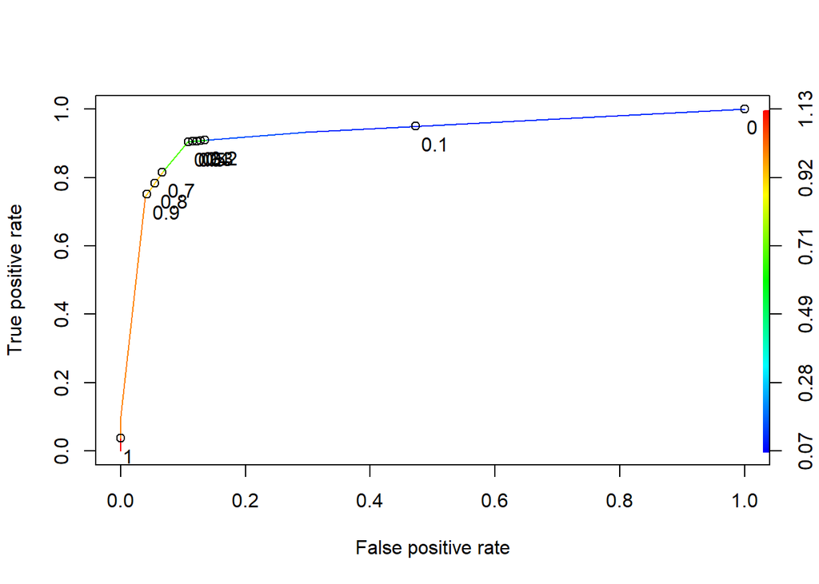

```r
#Plotting the ROC Curve
pred = prediction(PredictROC[,2], Test$satisfaction)
perf = performance(pred, "tpr", "fpr")
plot(perf, colorize = TRUE, print.cutoffs.at=seq(0,1,by=0.1),text.adj = c(-0.2,1.7))
```

**Confusion Matrix Table to Find Accuracy**: Evaluating the model’s accuracy.

```r
#Confusion Matrix table to find accuracy
#From the ROC Curve, we found 0.7 is the optimum threshold value for Cut-off.
table(Test$satisfaction, PredictROC[,2] > 0.7)
```

```
##
##                           FALSE  TRUE
##   neutral or dissatisfied 14003   570
##   satisfied                2919  8484
```

**Calculating Accuracy**: Detailed accuracy calculation.

```r
#Calculating Accuracy
Accuracy_avg_Tree = (14003+8484)/(14003+8484+570+2919)
Accuracy_avg_Tree
```

```
## [1] 0.8656837
```

**Calculating Sensitivity or Recall Value**: Calculating the recall metric.

```r
#Calculating Sensitivity or Recall value
Recall = (8484)/(8484+2919)
Recall
```

```
## [1] 0.7440147
```

**Calculating Precision Value**: Computing the precision of the model.

```r
#Calculating Precision Value
Precision = (8484)/(8484+570)
Precision
```

```
## [1] 0.9370444
```

**Calculating F-Measure**: Determining the F-Measure for model evaluation.

```r
#Calculating F-Measure
F.measure = (2*Recall*Precision)/(Recall+Precision)
F.measure
```

```
## [1] 0.8294471
```

**Calculating Specificity**: Assessing the specificity metric.

```r
#Calculating Specificity
Specificity = (14003)/(14003+570)
Specificity
```

```
## [1] 0.9608866
```

**Testing Data AUC-ROC (Area Under the Curve - Receiver Operator Characteristics)

```r
#Testing Data AUC-ROC(Area Under the Curve - Receiver operator Characteristics) value
AUC = as.numeric(performance(pred, "auc")@y.values)
AUC
```

```
## [1] 0.9270596
```